# STA4020A - Assignment 4

**Name: Chesia Anyika**

**ID: 665567**

```python
#libraries necessary
from pyDOE2 import fullfact
import numpy as np
import pandas as pd
import matplotlib.pyplot as plt
import itertools
import math
from statsmodels.formula.api import ols
import statsmodels.api as sm
from mpl_toolkits.mplot3d import Axes3D
```

# 1. Factorial Arrangement

## 1.1 Question

Consider a factorial experiment with the following factors and levels:

- Factor A: Temperature (2 levels: Low and High) - Fixed Effect
- Factor B: Humidity (2 levels: Low and High) - Fixed Effect
- Factor C: Light Exposure (2 levels: Low and High) - Fixed Effect

a. How many treatment combinations are there in this factorial experiment?

b. Write down the full factorial design matrix including all treatment combinations.

c. Assume you have conducted the experiment and collected data on the response variable.

- Perform a factorial ANOVA to analyze the effects of Factors A, B, and C on the response.
- Provide the ANOVA table summarizing the results.
- Interpret the p-values and determine which factors (if any) have statistically significant effects on the response variable.

## 1.2 Number of Treatment combinations

In a factorial experiment, the number of treatment combinations is the product of the levels of all factors. Here we have:

- Factor A: 2 levels (Low, High)
- Factor B: 2 levels (Low, High)
- Factor C: 2 levels (Low, High)

Thus the number of treatment combinations is:

$$ 2 \times 2 \times 2 = 8 $$

## 1.3 Full-Factorial Design Matrix

The full factorial design matrix includes **all possible combinations of the levels of the factors.** Here is the design matrix for Factors A, B, and C:

| **Combination** | Factor A (Temperature) | Factor B (Humidity) | Factor C (Light Exposure) |
| --- | --- | --- | --- |
| **1** | Low | Low | Low |
| **2** | High | Low | Low |
| **3** | Low | High | Low |
| **4** | High | High | Low |
| **5** | Low | Low | High |
| **6** | High | Low | High |
| **7** | Low | High | High |
| **8** | High | High | High |

I defined the function `create_full_factorial_design` to create a 2-level full factorial design plan, as per the above table.

```python
def create_full_factorial_design(factors, randomize=False):

    # Create a 2-level full factorial design
    design = fullfact([2]*len(factors))

    # Convert levels from 0/1 to -1/+1
    design = 2*design - 1

    # Convert design matrix to a DataFrame
    df = pd.DataFrame(design, columns=factors)

    # Randomize the design if needed
    if randomize:
        df = df.sample(frac=1).reset_index(drop=True)

    return df

factors = ['A', 'B', 'C']
df = create_full_factorial_design(factors, randomize = False)

# Save the design to an Excel file
df.to_excel('full_factorial_design.xlsx', index=False)

#View the resulting experimental design
print(df)
```

```
     A    B    C
0 -1.0 -1.0 -1.0
1  1.0 -1.0 -1.0
2 -1.0  1.0 -1.0
3  1.0  1.0 -1.0
4 -1.0 -1.0  1.0
5  1.0 -1.0  1.0
6 -1.0  1.0  1.0
7  1.0  1.0  1.0
```

The specific levels within the factors A, B and C are coded as -1 for Low and +1 for High, which is common practice in factorial designs to facilitate the analysis.

### 1.4 Simulation and Analysis of Response Data

#### 1.4.1 Simulation of Response Data

To perform Factorial ANOVA, we need to simulate response data $Y$ for each treatment combination, which I have taken to be **Germination Rate**. First, we define the effect sizes of each factor and all possibles interactions between factors. I defined the effect and interaction sizes such that:

1. **Effect Sizes per Factor:**
   - **Temperature (Factor A):**
     - When the temperature is at the "High" level (1), the response variable is expected to increase by 0.8 units.
     - When the temperature is at the "Low" level (-1), the response variable is expected to increase by 0.5 units.
   - **Humidity (Factor B):**
     - When humidity is at the "High" level (1), the response variable is expected to increase by 0.9 units.
     - When humidity is at the "Low" level (-1), the response variable is expected to increase by 0.6 units.
   - **Light Exposure (Factor C):**
     - When light exposure is at the "High" level (1), the response variable is expected to increase by 0.7 units.
     - When light exposure is at the "Low" level (-1), the response variable is expected to increase by 0.3 units.
2. **Interactions:**
   - **Interaction AB (Temperature and Humidity):**
     - The combined effect of temperature and humidity (when both factors are considered together) results in an additional increase of 0.1 units beyond the individual effects.
   - **Interaction AC (Temperature and Light Exposure):**
     - Considering both temperature and light exposure together, there is an additional increase of 0.2 units beyond their individual effects.
   - **Interaction BC (Humidity and Light Exposure):**
     - When humidity and light exposure are both present, there is an additional increase of 0.15 units beyond their individual effects.
   - **Three-Way Interaction (ABC):**
     - The simultaneous presence of temperature, humidity, and light exposure results in an additional increase of 0.3 units beyond the main effects and pairwise interactions.

```python
# Define effect sizes per factor
effect_A = {-1: 0.5, 1: 0.8}  # Temperature
effect_B = {-1: 0.6, 1: 0.9}  # Humidity
effect_C = {-1: 0.3, 1: 0.7}  # Light Exposure

# Define effect sizes per interaction
interaction_AB = 0.1  # Temperature and Humidity
interaction_AC = 0.2  # Temperature and Light Exposure
interaction_BC = 0.15  # Humidity and Light Exposure
interaction_ABC = 0.3  # Temperature, Humidity, and Light Exposure

# Set seed for reproducibility
np.random.seed(348)

# Number of samples
num_samples = 100

# Create factorial design
design = pd.DataFrame({
    'A': np.tile([-1, 1], num_samples // 2),
    'B': np.tile(np.repeat([-1, 1], num_samples // 4), 2),
    'C': np.repeat([-1, 1], num_samples // 2)
})

# Simulate the response data (germination rate Y)
design['Y'] = (design['A'].map(effect_A)
               + design['B'].map(effect_B)
               + design['C'].map(effect_C)
               + (interaction_AB * ((design['A'] == 1) & (design['B'] == 1)))
               + (interaction_AC * ((design['A'] == 1) & (design['C'] == 1)))
               + (interaction_BC * ((design['B'] == 1) & (design['C'] == 1)))
               + (interaction_ABC * ((design['A'] == 1) & (design['B'] == 1) & (design['C'] == 1)))
               + np.random.normal(loc=0.5, scale=0.1, size=num_samples)  # Adjust mean and variance as needed
               )

# Save the design to an Excel file
design.to_excel('full_factorial_design_Germination_rate.xlsx', index=False)

# Display the simulated data
print(design)
```

```
    A  B  C         Y
0  -1 -1 -1  1.825485
1   1 -1 -1  2.053733
2  -1 -1 -1  2.054405
3   1 -1 -1  2.168517
4  -1 -1 -1  2.036373
.. .. .. ..       ...
95  1  1  1  3.763916
96 -1  1  1  2.631667
97  1  1  1  3.498221
98 -1  1  1  2.684469
99  1  1  1  3.750987

[100 rows x 4 columns]
```

#### 1.4.2 Main Effects Plot

I defined a function that plots a **Main Effects Plot**, which is a bar chart displaying the main effects on the response variable Y. Positive values indicate an increase in the response Y when the factor is at its high level, while negative values indicate a decrease.

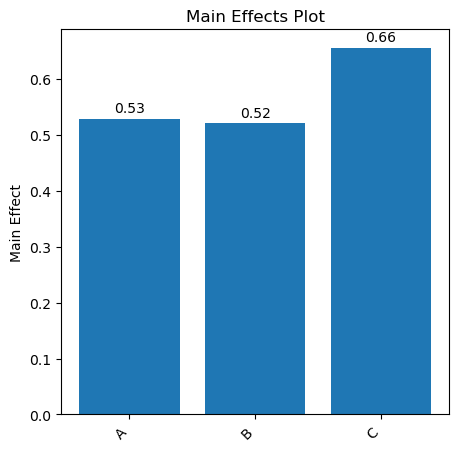

```python
#define main effects function
def main_effects_plot(excel_file, result_column):
    # Load data from excel
    df = pd.read_excel(excel_file)

    # Identify factors by excluding the result column
    factors = [col for col in df.columns if col != result_column]

    # Calculate main effects
    main_effects = {}
    for factor in factors:
        mean_plus = df[df[factor] == 1][result_column].mean()
        mean_minus = df[df[factor] == -1][result_column].mean()
        main_effects[factor] = mean_plus - mean_minus

    # Plot main effects
    fig, ax = plt.subplots(figsize=(5, 5))
    ax.bar(main_effects.keys(), main_effects.values())

    # Annotate the bars with their values
    for factor, value in main_effects.items():
        ax.text(factor, value + 0.01 * abs(value), '{:.2f}'.format(value), ha='center', va='bottom')

    ax.set_ylabel('Main Effect')
    ax.set_title('Main Effects Plot')
    plt.xticks(rotation=45, ha="right")
    plt.show()

#Execute function
excel_file = 'full_factorial_design_Germination_rate.xlsx'
result_column = 'Y'
main_effects_plot(excel_file, result_column)
```

**Interpretation**

The plot shows the response variable is affected positively by all the factors, indicating an increase in germination rate when al factors are at their high level.

The factor Light Exposure (C) has the greatest positive effect size on the response variable, with an effect size of $0.66$.

#### 1.4.3 Interactions Plot

I defined another function to explore two-way interactions in our factorial design.

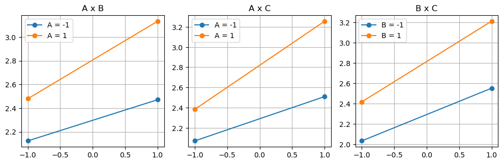

```python
#define interactions plot
def interaction_point_plot(excel_file, result_column):
    df = pd.read_excel(excel_file)
    factors = [col for col in df.columns if col != result_column]
    interactions = list(itertools.combinations(factors, 2))

    # Calculate number of rows and columns for subplots
    cols = 3
    rows = math.ceil(len(interactions) / cols)
    fig, axs = plt.subplots(rows, cols, figsize=(10, 10*rows/3))

    for idx, interaction in enumerate(interactions):
        row = idx // cols
        col = idx % cols

        ax = axs[row, col] if rows > 1 else axs[col]

        for level in [-1, 1]:
            subset = df[df[interaction[0]] == level]
            ax.plot(subset[interaction[1]].unique(), subset.groupby(interaction[1])[result_column].mean(), 'o-', label=f'{interaction[0]} = {level}')

        ax.set_title(f'{interaction[0]} x {interaction[1]}')
        ax.legend()
        ax.grid(True)

    # Handle any remaining axes (if there's no data to plot in them)
    for idx in range(len(interactions), rows*cols):
        row = idx // cols
        col = idx % cols
        axs[row, col].axis('off')

    plt.tight_layout()
    plt.show()

#Execute function
interaction_point_plot(excel_file, result_column)
```

### 1.5 ANOVA Model

After getting an overview of the data, we can conduct the ANOVA model building process. The process involves fitting a linear model to the data and then conducting ANOVA to test the significance of each factor and interaction. We do this to test the assumptions we built from the visualization step.

```python
df = pd.read_excel(excel_file)

# Fit the model
formula = 'Y ~ A*B*C'
model = ols(formula, data=df).fit()

# Perform ANOVA and print the results
anova_table = sm.stats.anova_lm(model, typ=1)
anova_table
```

|  | df | sum_sq | mean_sq | F | PR(>F) |
| --- | --- | --- | --- | --- | --- |
| A | 1.0 | 7.002482 | 7.002482 | 789.326231 | 6.312789e-47 |
| B | 1.0 | 6.265732 | 6.265732 | 706.279143 | 6.025256e-45 |
| A:B | 1.0 | 0.587078 | 0.587078 | 66.175925 | 1.886524e-12 |
| C | 1.0 | 10.752862 | 10.752862 | 1212.072509 | 9.220673e-55 |
| A:C | 1.0 | 1.178799 | 1.178799 | 132.875352 | 1.495843e-19 |
| B:C | 1.0 | 0.415497 | 0.415497 | 46.835207 | 8.422367e-10 |
| A:B:C | 1.0 | 0.099869 | 0.099869 | 11.257361 | 1.153675e-03 |
| Residual | 92.0 | 0.816175 | 0.008871 | NaN | NaN |

Thus, all the factors, factor pairs and the factor triple significantly affect the outcome response Y.

### 1.6 Model Diagnostics

I defined the function `diagnostic_plots` that creates three diagnostic plots to assess the fit of our model. The model creates three plots, which are:

**Residuals vs. Predicted plot:**

This is a scatter plot of predicted values against residuals. Ideally, the points should be randomly dispersed around the horizontal line y=0, without any discernible pattern.

**Residuals vs. Runs plot**

This plot checks for any patterns in the residuals that may suggest dependence on the order of data collection, which could indicate time-related trends or serial correlation.

**Q-Q plot**

This is used to assess the normality of the residuals. Points following a straight line (the 45-degree line indicated by line='45') suggest that the residuals are normally distributed.

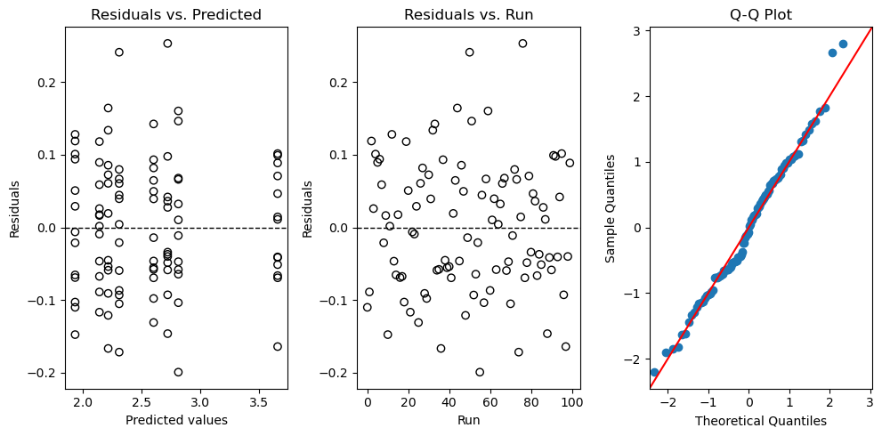

```python
def diagnostic_plots(model):
    # Extract residuals and predicted values from the model
    residuals = model.resid
    predicted = model.fittedvalues

    # Create subplots
    fig, axs = plt.subplots(1, 3, figsize=(10, 5))

    # Residuals vs Predicted
    axs[0].scatter(predicted, residuals, edgecolors='k', facecolors='none')
    axs[0].axhline(y=0, color='k', linestyle='dashed', linewidth=1)
    axs[0].set_title('Residuals vs. Predicted')
    axs[0].set_xlabel('Predicted values')
    axs[0].set_ylabel('Residuals')

    # Residuals vs. Runs (Order of Data Collection)
    axs[1].scatter(range(len(residuals)), residuals, edgecolors='k', facecolors='none')
    axs[1].axhline(y=0, color='k', linestyle='dashed', linewidth=1)
    axs[1].set_title('Residuals vs. Run')
    axs[1].set_xlabel('Run')
    axs[1].set_ylabel('Residuals')

    # Q-Q plot
    sm.qqplot(residuals, line='45', fit=True, ax=axs[2])
    axs[2].set_title('Q-Q Plot')

    plt.tight_layout()
    plt.show()

#execute function
diagnostic_plots(model)
```

**Interpretation**

1. **Residuals vs. Predicted Plot**
   - The points appear to be fairly randomly dispersed around the y=0y=0 line, suggesting that the residuals do not exhibit any obvious patterns. This is a good indication that the model does not suffer from heteroscedasticity or non-linearity in the residuals.
2. **Residuals vs. Run Plot**
   - The residuals appear to be randomly scattered, without any obvious pattern or trend over the order of data collection. This suggests that there is no significant time-related trend or serial correlation affecting the residuals.
3. **Q-Q Plot**
   - Most of the points fall along the 45-degree line, suggesting that the residuals are approximately normally distributed. There are some deviations at the tails, which might indicate slight departures from normality, but overall the normality assumption appears reasonably met.